# GIS in R final exam: Hints

For each of the memos below, I have provided the lessons and sections in which the methods were taught and the result that a correct answer would return.

## Memo 1

- [Preliminary Lesson 2: Environment & Functions / Naming conventions](https://evansbrians.github.io/gis_2026/module_0/0.2_environment_and_functions/#naming-conventions)
- [Course style guide](https://evansbrians.github.io/gis_2026/resources/course_style_guide/)

## Memo 2

**Attaching the packages**

- [Preliminary Lesson 2: Environment & Functions / Packages of functions](https://evansbrians.github.io/gis_2026/module_0/0.2_environment_and_functions/#packages-of-functions)
- [1.3 R Objects / Package namespaces and attached package environments](https://evansbrians.github.io/gis_2026/module_1/1.3_objects/#package-namespaces-and-attached-package-environments)

**Setting the *tmap* mode**

- [3.5 Introduction to tmap / From static maps to interactive maps](https://evansbrians.github.io/gis_2026/module_3/3.5_introduction_to_tmap/#from-static-maps-to-interactive-maps)

## Memo 3

**`nlcd_key`**

- [1.4 Importing, exploring, and exporting data / Review: Read csv files](https://evansbrians.github.io/gis_2026/module_1/1.4_importing_exploring_exporting/#review-read-csv-files)
- [2.1 Introduction to subsetting and extraction / Subset data frame columns](https://evansbrians.github.io/gis_2026/module_2/2.1_subsetting_and_extraction/#subset-data-frame-columns)
- [1.5 Assignments / Rename with `rename()`](https://evansbrians.github.io/gis_2026/module_1/1.5_assignments/#rename-with-rename)

**`lc`**

- [6.1 Introduction to rasters with terra / Reading raster data](https://evansbrians.github.io/gis_2026/module_6/6.1_introduction_to_rasters/#reading-raster-data)
- [6.2 Categorical rasters / Categorical raster structure](https://evansbrians.github.io/gis_2026/module_6/6.2_categorical_rasters/#categorical-raster-structure)
- [6.2 Categorical rasters / Merging classes](https://evansbrians.github.io/gis_2026/module_6/6.2_categorical_rasters/#merging-classes)

**`dem`**

- [6.1 Introduction to rasters with terra / Layers and values](https://evansbrians.github.io/gis_2026/module_6/6.1_introduction_to_rasters/#layers-and-values)
- [6.3 Changing the grid / Projecting a raster](https://evansbrians.github.io/gis_2026/module_6/6.3_changing_the_grid/#projecting-a-raster)
- [6.3 Changing the grid / Resampling to a target grid](https://evansbrians.github.io/gis_2026/module_6/6.3_changing_the_grid/#resampling-to-a-target-grid)
- [6.3 Changing the grid / Moving fine cells onto a coarse grid](https://evansbrians.github.io/gis_2026/module_6/6.3_changing_the_grid/#moving-fine-cells-onto-a-coarse-grid)

**What your answer should look like**

```
# A tibble: 20 × 2
      id land_cover
   <dbl> <chr>
 1    11 Open water
 2    12 Perennial ice/snow
 3    21 Developed, open space
 4    22 Developed, low intensity
 5    23 Developed, medium intensity
 6    24 Developed, high intensity
 7    31 Barren Land (Rock/Sand/Clay)
 8    41 Deciduous Forest
 9    42 Evergreen Forest
10    43 Mixed Forest
11    51 Dwarf Scrub*
12    52 Shrub/Scrub
13    71 Grassland/Herbaceous
14    72 Sedge/Herbaceous*
15    73 Lichens*
16    74 Moss*
17    81 Pasture/Hay
18    82 Cultivated Crops
19    90 Woody Wetlands
20    95 Emergent Herbaceous Wetlands
```

```
class       : SpatRaster
size        : 755, 604, 1  (nrow, ncol, nlyr)
resolution  : 30.04599, 30.04599  (x, y)
extent      : 316274.3, 334422.1, 4295633, 4318318  (xmin, xmax, ymin, ymax)
coord. ref. : WGS 84 / UTM zone 18N (EPSG:32618)
source(s)   : memory
categories  : label
name        :                   land_cover
min value   :                   Open water
max value   : Emergent Herbaceous Wetlands
```

```
class       : SpatRaster
size        : 755, 604, 1  (nrow, ncol, nlyr)
resolution  : 30.04599, 30.04599  (x, y)
extent      : 316274.3, 334422.1, 4295633, 4318318  (xmin, xmax, ymin, ymax)
coord. ref. : WGS 84 / UTM zone 18N (EPSG:32618)
source(s)   : memory
name        :  elevation
min value   :  -7.806356
max value   : 130.685471
```

## Memo 4

**Iterating over the four files**

- [4.4 Iteration with purrr / Combining what differs into an object](https://evansbrians.github.io/gis_2026/module_4/4.4_iteration/#combining-what-differs-into-an-object)
- [4.4 Iteration with purrr / Applying a function to every element](https://evansbrians.github.io/gis_2026/module_4/4.4_iteration/#applying-a-function-to-every-element)
- [4.4 Iteration with purrr / A lambda function](https://evansbrians.github.io/gis_2026/module_4/4.4_iteration/#a-lambda-function)

**Reading and preprocessing each file**

- [3.2 Introduction to spatial vector data / Read spatial vector files](https://evansbrians.github.io/gis_2026/module_3/3.2_introduction_to_shapefiles/#read-spatial-vector-files)
- [2.1 Introduction to subsetting and extraction / Subset data frame columns](https://evansbrians.github.io/gis_2026/module_2/2.1_subsetting_and_extraction/#subset-data-frame-columns)
- [3.4 The coordinate reference system / Transform data to another CRS](https://evansbrians.github.io/gis_2026/module_3/3.4_crs/#transform-data-to-another-crs)

**Globally assigning the four objects**

- [2.1 Introduction to subsetting and extraction / Extraction while reading in data](https://evansbrians.github.io/gis_2026/module_2/2.1_subsetting_and_extraction/#extraction-while-reading-in-data)

**What your answer should look like**

```
<environment: R_GlobalEnv>
```

```
Simple feature collection with 40 features and 1 field
Geometry type: POINT
Dimension:     XY
Bounding box:  xmin: 319345 ymin: 4301529 xmax: 332199.4 ymax: 4316060
Projected CRS: WGS 84 / UTM zone 18N
First 10 features:
                            name                 geometry
1                         Takoma POINT (325175.9 4316060)
2             Friendship Heights   POINT (319345 4314349)
3                    Fort Totten POINT (326500.6 4313340)
4                  Tenleytown-AU POINT (319786.7 4313158)
5                   Van Ness-UDC POINT (321211.5 4312505)
6           Georgia Ave Petworth POINT (324622.8 4311781)
7                 Cleveland Park POINT (321618.6 4311552)
8                  Brookland-CUA POINT (327119.9 4311257)
9               Columbia Heights POINT (323811.1 4310734)
10 Woodley Park-Zoo Adams Morgan   POINT (322082 4310467)
```

```
Simple feature collection with 457 features and 1 field
Geometry type: MULTIPOLYGON
Dimension:     XY
Bounding box:  xmin: 316307.5 ymin: 4296878 xmax: 333240.8 ymax: 4318263
Projected CRS: WGS 84 / UTM zone 18N
First 10 features:
                                     name                       geometry
1                           Beach Parkway MULTIPOLYGON (((322975.6 43...
2                            North Portal MULTIPOLYGON (((323615.9 43...
3  Rock Creek Park & Piney Branch Parkway MULTIPOLYGON (((321467.1 43...
4                     Piney Branch Portal MULTIPOLYGON (((325106.9 43...
5                       Pinehurst Parkway MULTIPOLYGON (((322004.2 43...
6                     Piney Branch Portal MULTIPOLYGON (((325145.9 43...
7          Battleground National Cemetery MULTIPOLYGON (((324456.7 43...
8                            Curb Parking MULTIPOLYGON (((320137 4315...
9                      Chevy Chase Circle MULTIPOLYGON (((320014.7 43...
10                               Triangle MULTIPOLYGON (((320081.1 43...
```

```
Simple feature collection with 34021 features and 1 field
Geometry type: LINESTRING
Dimension:     XY
Bounding box:  xmin: 316533.6 ymin: 4295806 xmax: 334394.5 ymax: 4318232
Projected CRS: WGS 84 / UTM zone 18N
First 10 features:
           name                       geometry
1     Bryant St LINESTRING (326271.5 430995...
2  Reservoir Rd LINESTRING (319997.5 430913...
3       13th St LINESTRING (324002.2 430791...
4          <NA> LINESTRING (322174.5 430617...
5       19th St LINESTRING (328521.3 430679...
6    Madison St LINESTRING (326705.3 431416...
7          <NA> LINESTRING (325836.1 430891...
8          <NA> LINESTRING (328705.1 430478...
9          <NA> LINESTRING (325115.2 430960...
10         <NA> LINESTRING (327260.1 431208...
```

```
Simple feature collection with 8 features and 1 field
Geometry type: POLYGON
Dimension:     XY
Bounding box:  xmin: 316264.8 ymin: 4295630 xmax: 334427.9 ymax: 4318311
Projected CRS: WGS 84 / UTM zone 18N
    name                       geometry
1 Ward 8 POLYGON ((327039 4305095, 3...
2 Ward 6 POLYGON ((325708.3 4304449,...
3 Ward 7 POLYGON ((331651.3 4309530,...
4 Ward 2 POLYGON ((323686.2 4305714,...
5 Ward 1 POLYGON ((323602.6 4311803,...
6 Ward 5 POLYGON ((327447.2 4313924,...
7 Ward 3 POLYGON ((321670.6 4313992,...
8 Ward 4 POLYGON ((323251.2 4318311,...
```

## Memo 5

**Reading and renaming the fields**

- [2.1 Introduction to subsetting and extraction / Extraction while reading in data](https://evansbrians.github.io/gis_2026/module_2/2.1_subsetting_and_extraction/#extraction-while-reading-in-data)
- [1.5 Assignments / Rename with `rename()`](https://evansbrians.github.io/gis_2026/module_1/1.5_assignments/#rename-with-rename)

**Removing records**

- [2.1 Introduction to subsetting and extraction / Subset data frame rows](https://evansbrians.github.io/gis_2026/module_2/2.1_subsetting_and_extraction/#subset-data-frame-rows)

**Converting and filtering on diameter**

- [2.2 Introduction to mutation / Add or modify a column](https://evansbrians.github.io/gis_2026/module_2/2.2_mutation/#add-or-modify-a-column)
- [2.1 Introduction to subsetting and extraction / Subset data frame columns](https://evansbrians.github.io/gis_2026/module_2/2.1_subsetting_and_extraction/#subset-data-frame-columns)

**Classifying the genera**

- [5.4 Categorizing spatial data / More than two classes](https://evansbrians.github.io/gis_2026/module_5/5.4_categorizing_spatial_data/#more-than-two-classes)

**Converting to a simple features object within `wards`**

- [3.2 Introduction to spatial vector data / Data frames to simple features objects](https://evansbrians.github.io/gis_2026/module_3/3.2_introduction_to_shapefiles/#data-frames-to-simple-features-objects)
- [3.4 The coordinate reference system / Transform data to another CRS](https://evansbrians.github.io/gis_2026/module_3/3.4_crs/#transform-data-to-another-crs)
- [4.1 Spatial filtering / Filtering on location](https://evansbrians.github.io/gis_2026/module_4/4.1_spatial_filtering/#filtering-on-location)

**What your answer should look like**

```
Simple feature collection with 53918 features and 1 field
Geometry type: POINT
Dimension:     XY
Bounding box:  xmin: 316761.4 ymin: 4298100 xmax: 334382.4 ymax: 4318167
Projected CRS: WGS 84 / UTM zone 18N
# A tibble: 53,918 × 2
   genus           geometry
 * <chr>        <POINT [m]>
 1 other (327390.5 4305257)
 2 maple (327554.3 4306112)
 3 other (326170.2 4305939)
 4 oak     (323446 4308611)
 5 other (325752.8 4306066)
 6 other (326565.6 4305407)
 7 other (326573.3 4306305)
 8 oak   (326005.5 4306049)
 9 oak   (323276.6 4308732)
10 oak   (322737.7 4311343)
# ℹ 53,908 more rows
```

## Memo 6

**The tibble of counts**

- [4.3 Spatial joins / Two functions, two questions](https://evansbrians.github.io/gis_2026/module_4/4.3_spatial_joins/#two-functions-two-questions)
- [5.1 Focus on points / Records that repeat](https://evansbrians.github.io/gis_2026/module_5/5.1_focus_on_points/#records-that-repeat)
- [2.3 Grouped operations and summarizing / Count the records in each group](https://evansbrians.github.io/gis_2026/module_2/2.3_grouped_operations_and_summarize/#count-the-records-in-each-group)
- [2.4 Reshaping data frames / Pivot from long to wide form](https://evansbrians.github.io/gis_2026/module_2/2.4_reshaping_data_frames/#pivot-from-long-to-wide-form)
- [2.2 Introduction to mutation / Add or modify a column](https://evansbrians.github.io/gis_2026/module_2/2.2_mutation/#add-or-modify-a-column)
- [1.4 Importing, exploring, and exporting data / Ordering](https://evansbrians.github.io/gis_2026/module_1/1.4_importing_exploring_exporting/#ordering)

**The faceted bar plot**

- [2.5 Introduction to data visualization with ggplot2 / Geometries](https://evansbrians.github.io/gis_2026/module_2/2.5_intro_to_data_vis/#geometries)
- [2.5 Introduction to data visualization with ggplot2 / Facets](https://evansbrians.github.io/gis_2026/module_2/2.5_intro_to_data_vis/#facets)
- [2.5 Introduction to data visualization with ggplot2 / Labels](https://evansbrians.github.io/gis_2026/module_2/2.5_intro_to_data_vis/#labels)
- [4.5 Cartography with ggplot2 and tmap / Comparing groups with facets](https://evansbrians.github.io/gis_2026/module_4/4.5_cartography/#comparing-groups-with-facets)

**What your answer should look like**

```
# A tibble: 8 × 4
  name   maple   oak total
  <chr>  <int> <int> <int>
1 Ward 1   435  1307  3108
2 Ward 2   667  1694  4878
3 Ward 3  2677  4996 12315
4 Ward 4  1492  4325  9427
5 Ward 5  1130  2939  6780
6 Ward 6  1243  2039  5533
7 Ward 7  1965  2605  7511
8 Ward 8   732  1760  4366
```

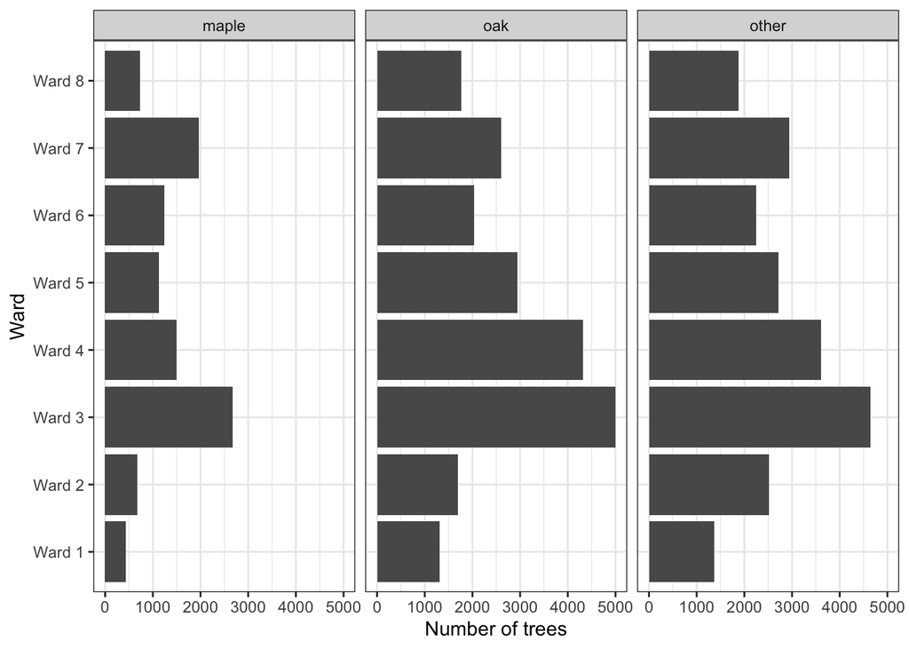

*Note: I chose to flip the coordinates here, but you are not required to do so.*

## Memo 7

**Trees per square kilometer**

- [4.3 Spatial joins / Counting features inside features](https://evansbrians.github.io/gis_2026/module_4/4.3_spatial_joins/#counting-features-inside-features)
- [4.2 Non-spatial joins / Mutating joins](https://evansbrians.github.io/gis_2026/module_4/4.2_nonspatial_joins/#mutating-joins)
- [3.6 Geometric operations with sf / Area](https://evansbrians.github.io/gis_2026/module_3/3.6_geometric_operations/#area)

**The ggplot map**

- [4.2 Non-spatial joins / Joining attributes to spatial data and mapping](https://evansbrians.github.io/gis_2026/module_4/4.2_nonspatial_joins/#joining-attributes-to-spatial-data-and-mapping)
- [4.5 Cartography with ggplot2 and tmap / Encoding a value](https://evansbrians.github.io/gis_2026/module_4/4.5_cartography/#encoding-a-value)
- [2.5 Introduction to data visualization with ggplot2 / Labels](https://evansbrians.github.io/gis_2026/module_2/2.5_intro_to_data_vis/#labels)

**What your answer should look like**

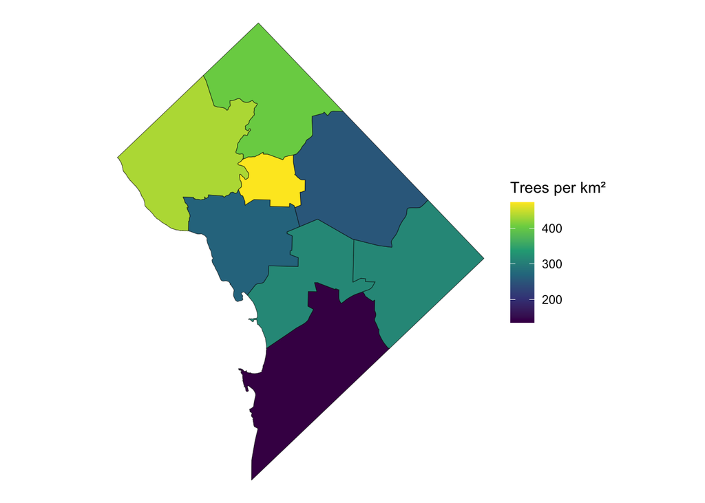

## Memo 8

**Parkland within each ward**

- [3.6 Geometric operations with sf / Spatial aggregation](https://evansbrians.github.io/gis_2026/module_3/3.6_geometric_operations/#spatial-aggregation)
- [5.3 Focus on polygons / Subsetting and clipping](https://evansbrians.github.io/gis_2026/module_5/5.3_focus_on_polygons/#subsetting-and-clipping)
- [5.3 Focus on polygons / What the fields mean after a cut](https://evansbrians.github.io/gis_2026/module_5/5.3_focus_on_polygons/#what-the-fields-mean-after-a-cut)
- [3.6 Geometric operations with sf / Area](https://evansbrians.github.io/gis_2026/module_3/3.6_geometric_operations/#area)
- [1.4 Importing, exploring, and exporting data / Ordering](https://evansbrians.github.io/gis_2026/module_1/1.4_importing_exploring_exporting/#ordering)

**What your answer should look like**

```
# A tibble: 8 × 2
  ward   parkland_ha
  <chr>        <dbl>
1 Ward 1        42.3
2 Ward 2       442.
3 Ward 3       582.
4 Ward 4       546.
5 Ward 5       363.
6 Ward 6       168.
7 Ward 7       492.
8 Ward 8       214.
```

## Memo 9

**Trees on and off National Park Service land**

- [4.3 Spatial joins / Counting features inside features](https://evansbrians.github.io/gis_2026/module_4/4.3_spatial_joins/#counting-features-inside-features)
- [5.4 Categorizing spatial data / Two classes](https://evansbrians.github.io/gis_2026/module_5/5.4_categorizing_spatial_data/#two-classes)
- [2.3 Grouped operations and summarizing / Count the records in each group](https://evansbrians.github.io/gis_2026/module_2/2.3_grouped_operations_and_summarize/#count-the-records-in-each-group)

**`trees_no_nps`**

- [4.1 Spatial filtering / The condition is a spatial predicate](https://evansbrians.github.io/gis_2026/module_4/4.1_spatial_filtering/#the-condition-is-a-spatial-predicate)
- [4.1 Spatial filtering / Combining the second object](https://evansbrians.github.io/gis_2026/module_4/4.1_spatial_filtering/#combining-the-second-object)

**The clustered interactive map**

- [5.1 Focus on points / Mapping many points](https://evansbrians.github.io/gis_2026/module_5/5.1_focus_on_points/#mapping-many-points)
- [3.5 Introduction to tmap / Build a tmap](https://evansbrians.github.io/gis_2026/module_3/3.5_introduction_to_tmap/#build-a-tmap)

**What your answer should look like**

```
# A tibble: 2 × 2
  land_owner                n
  <chr>                 <int>
1 National Park Service   553
2 other                 53365
```

```
Simple feature collection with 53365 features and 1 field
Geometry type: POINT
Dimension:     XY
Bounding box:  xmin: 316761.4 ymin: 4298100 xmax: 334382.4 ymax: 4318167
Projected CRS: WGS 84 / UTM zone 18N
# A tibble: 53,365 × 2
   genus           geometry
 * <chr>        <POINT [m]>
 1 other (327390.5 4305257)
 2 maple (327554.3 4306112)
 3 other (326170.2 4305939)
 4 oak     (323446 4308611)
 5 other (325752.8 4306066)
 6 other (326565.6 4305407)
 7 other (326573.3 4306305)
 8 oak   (326005.5 4306049)
 9 oak   (323276.6 4308732)
10 oak   (322737.7 4311343)
# ℹ 53,355 more rows
```

[interactive chart not shown]

*Note: I turned off popups here with `popup.vars = FALSE`, you were not asked to do so (I did it because the file size was too large to post to the website).*

## Memo 10

**`general_lc`**

- [6.2 Categorical rasters / Merging classes](https://evansbrians.github.io/gis_2026/module_6/6.2_categorical_rasters/#merging-classes)
- [5.4 Categorizing spatial data / More than two classes](https://evansbrians.github.io/gis_2026/module_5/5.4_categorizing_spatial_data/#more-than-two-classes)

**`forest`**

- [7.1 Map algebra / Local operations](https://evansbrians.github.io/gis_2026/module_7/7.1_map_algebra/#local-operations)

**`forest_distance`**

- [7.3 Raster operations / Calculating distance surfaces](https://evansbrians.github.io/gis_2026/module_7/7.3_more_raster_tools/#calculating-distance-surfaces)
- [6.1 Introduction to rasters with terra / Layers and values](https://evansbrians.github.io/gis_2026/module_6/6.1_introduction_to_rasters/#layers-and-values)
- [6.4 Rasters and vectors together / Cropping and masking with vector boundaries](https://evansbrians.github.io/gis_2026/module_6/6.4_rasters_and_vectors/#cropping-and-masking-with-vector-boundaries)

**The ggplot map**

- [6.1 Introduction to rasters with terra / Visualizing raster data](https://evansbrians.github.io/gis_2026/module_6/6.1_introduction_to_rasters/#visualizing-raster-data)
- [2.5 Introduction to data visualization with ggplot2 / Labels](https://evansbrians.github.io/gis_2026/module_2/2.5_intro_to_data_vis/#labels)

**`trees_no_forests`**

- [7.3 Raster operations / Reading a surface at points](https://evansbrians.github.io/gis_2026/module_7/7.3_more_raster_tools/#reading-a-surface-at-points)
- [6.4 Rasters and vectors together / Extracting raster values at vector locations](https://evansbrians.github.io/gis_2026/module_6/6.4_rasters_and_vectors/#extracting-raster-values-at-vector-locations)

**The median distance to forest**

- [7.3 Raster operations / Sampling raster cells](https://evansbrians.github.io/gis_2026/module_7/7.3_more_raster_tools/#sampling-raster-cells)
- [2.3 Grouped operations and summarizing / Summarize](https://evansbrians.github.io/gis_2026/module_2/2.3_grouped_operations_and_summarize/#summarize)

**What your answer should look like**

```
class       : SpatRaster
size        : 755, 604, 1  (nrow, ncol, nlyr)
resolution  : 30.04599, 30.04599  (x, y)
extent      : 316274.3, 334422.1, 4295633, 4318318  (xmin, xmax, ymin, ymax)
coord. ref. : WGS 84 / UTM zone 18N (EPSG:32618)
source(s)   : memory
categories  : label
name        : general_class
min value   :         water
max value   :         other
```

```
class       : SpatRaster
size        : 755, 604, 1  (nrow, ncol, nlyr)
resolution  : 30.04599, 30.04599  (x, y)
extent      : 316274.3, 334422.1, 4295633, 4318318  (xmin, xmax, ymin, ymax)
coord. ref. : WGS 84 / UTM zone 18N (EPSG:32618)
source(s)   : memory
name        : general_class
min value   :             1
max value   :             1
```

```
class       : SpatRaster
size        : 755, 604, 1  (nrow, ncol, nlyr)
resolution  : 30.04599, 30.04599  (x, y)
extent      : 316274.3, 334422.1, 4295633, 4318318  (xmin, xmax, ymin, ymax)
coord. ref. : WGS 84 / UTM zone 18N (EPSG:32618)
source(s)   : memory
name        :  distance_m
min value   :           0
max value   : 2593.371338
```

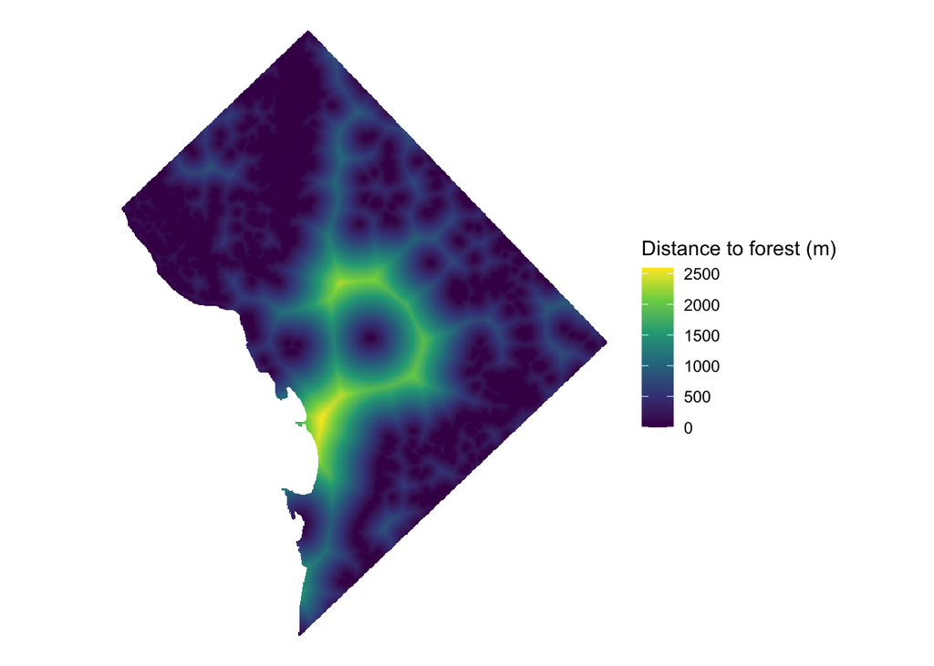

```
Simple feature collection with 44992 features and 1 field
Geometry type: POINT
Dimension:     XY
Bounding box:  xmin: 316879.9 ymin: 4298100 xmax: 334353.1 ymax: 4318167
Projected CRS: WGS 84 / UTM zone 18N
# A tibble: 44,992 × 2
   genus           geometry
   <chr>        <POINT [m]>
 1 other (327390.5 4305257)
 2 maple (327554.3 4306112)
 3 other (326170.2 4305939)
 4 oak     (323446 4308611)
 5 other (325752.8 4306066)
 6 other (326565.6 4305407)
 7 other (326573.3 4306305)
 8 oak   (326005.5 4306049)
 9 oak   (323276.6 4308732)
10 oak   (322737.7 4311343)
# ℹ 44,982 more rows
```

```
  median_distance
1        346.4852
```

## Memo 11

**`forest_patches`**

- [7.3 Raster operations / Identifying patches](https://evansbrians.github.io/gis_2026/module_7/7.3_more_raster_tools/#identifying-patches)

**The tibble of patch statistics**

- [7.3 Raster operations / Measuring the patches](https://evansbrians.github.io/gis_2026/module_7/7.3_more_raster_tools/#measuring-the-patches)
- [6.1 Introduction to rasters with terra / Raster resolution and cell area](https://evansbrians.github.io/gis_2026/module_6/6.1_introduction_to_rasters/#raster-resolution-and-cell-area)
- [2.3 Grouped operations and summarizing / Summarize](https://evansbrians.github.io/gis_2026/module_2/2.3_grouped_operations_and_summarize/#summarize)

**What your answer should look like**

```
class       : SpatRaster
size        : 755, 604, 1  (nrow, ncol, nlyr)
resolution  : 30.04599, 30.04599  (x, y)
extent      : 316274.3, 334422.1, 4295633, 4318318  (xmin, xmax, ymin, ymax)
coord. ref. : WGS 84 / UTM zone 18N (EPSG:32618)
source(s)   : memory
name        : patches
min value   :       1
max value   :    1935
```

```
# A tibble: 1 × 3
  n_patches largest at_least_10_ha
      <int>   <dbl>          <int>
1      1462    652.             66
```

## Memo 12

**`slope`**

- [7.2 Terrain analysis and visualization / Slope and aspect](https://evansbrians.github.io/gis_2026/module_7/7.2_terrain/#slope-and-aspect)

**Mean slope of each class**

- [7.1 Map algebra / Zonal and global summaries](https://evansbrians.github.io/gis_2026/module_7/7.1_map_algebra/#zonal-and-global-summaries)

**`forest_cover`**

- [7.1 Map algebra / Local operations](https://evansbrians.github.io/gis_2026/module_7/7.1_map_algebra/#local-operations)
- [7.1 Map algebra / Focal operations](https://evansbrians.github.io/gis_2026/module_7/7.1_map_algebra/#focal-operations)

**What your answer should look like**

```
class       : SpatRaster
size        : 755, 604, 1  (nrow, ncol, nlyr)
resolution  : 30.04599, 30.04599  (x, y)
extent      : 316274.3, 334422.1, 4295633, 4318318  (xmin, xmax, ymin, ymax)
coord. ref. : WGS 84 / UTM zone 18N (EPSG:32618)
source(s)   : memory
name        :     slope
min value   :         0
max value   : 28.037593
```

```
  general_class    slope
1         water 1.664600
2     developed 3.007839
3        forest 7.892433
4         other 2.193914
```

```
class       : SpatRaster
size        : 755, 604, 1  (nrow, ncol, nlyr)
resolution  : 30.04599, 30.04599  (x, y)
extent      : 316274.3, 334422.1, 4295633, 4318318  (xmin, xmax, ymin, ymax)
coord. ref. : WGS 84 / UTM zone 18N (EPSG:32618)
source(s)   : memory
name        : forest_cover
min value   :            0
max value   :            1
```

## Memo 13

**`tree_counts`**

- [6.4 Rasters and vectors together / Converting between sf and SpatVector objects](https://evansbrians.github.io/gis_2026/module_6/6.4_rasters_and_vectors/#converting-between-sf-and-spatvector-objects)
- [6.4 Rasters and vectors together / Rasterizing vector features](https://evansbrians.github.io/gis_2026/module_6/6.4_rasters_and_vectors/#rasterizing-vector-features)
- [7.4 Kernel density estimation / Counting records](https://evansbrians.github.io/gis_2026/module_7/7.4_kernel_density/#counting-records)
- [6.3 Changing the grid / Aggregating and disaggregating rasters](https://evansbrians.github.io/gis_2026/module_6/6.3_changing_the_grid/#aggregating-and-disaggregating-rasters)
- [6.4 Rasters and vectors together / Cropping and masking with vector boundaries](https://evansbrians.github.io/gis_2026/module_6/6.4_rasters_and_vectors/#cropping-and-masking-with-vector-boundaries)

**`street_points`**

- [2.1 Introduction to subsetting and extraction / Subset data frame rows](https://evansbrians.github.io/gis_2026/module_2/2.1_subsetting_and_extraction/#subset-data-frame-rows)
- [3.3 Constructing and converting simple features / From lines & polygons to points](https://evansbrians.github.io/gis_2026/module_3/3.3_constructing_and_converting_shapefiles/#from-lines-polygons-to-points)
- [2.4 Reshaping data frames / Remove duplicates](https://evansbrians.github.io/gis_2026/module_2/2.4_reshaping_data_frames/#remove-duplicates)

**`sampling_points`**

- [6.4 Rasters and vectors together / Extracting raster values at vector locations](https://evansbrians.github.io/gis_2026/module_6/6.4_rasters_and_vectors/#extracting-raster-values-at-vector-locations)
- [7.3 Raster operations / Reading a surface at points](https://evansbrians.github.io/gis_2026/module_7/7.3_more_raster_tools/#reading-a-surface-at-points)
- [2.1 Introduction to subsetting and extraction / Subset data frame rows](https://evansbrians.github.io/gis_2026/module_2/2.1_subsetting_and_extraction/#subset-data-frame-rows)

**What your answer should look like**

```
class       : SpatRaster
size        : 378, 302, 1  (nrow, ncol, nlyr)
resolution  : 60.09198, 60.09198  (x, y)
extent      : 316274.3, 334422.1, 4295603, 4318318  (xmin, xmax, ymin, ymax)
coord. ref. : WGS 84 / UTM zone 18N (EPSG:32618)
source(s)   : memory
name        : trees
min value   :     0
max value   :    24
```

```
Simple feature collection with 18531 features and 0 fields
Geometry type: POINT
Dimension:     XY
Bounding box:  xmin: 316533.6 ymin: 4295806 xmax: 334394.5 ymax: 4318232
Projected CRS: WGS 84 / UTM zone 18N
First 10 features:
                   geometry
1  POINT (326271.5 4309953)
2  POINT (326313.6 4309952)
3  POINT (319997.5 4309131)
4  POINT (319854.3 4309139)
5  POINT (324002.2 4307918)
6  POINT (324002.4 4307931)
7  POINT (328521.3 4306795)
8  POINT (328522.7 4306848)
9  POINT (326705.3 4314164)
10 POINT (326818.6 4314073)
```

```
Simple feature collection with 2385 features and 3 fields
Geometry type: POINT
Dimension:     XY
Bounding box:  xmin: 317287 ymin: 4298795 xmax: 334154.8 ymax: 4317850
Projected CRS: WGS 84 / UTM zone 18N
First 10 features:
                   geometry trees     slope forest_cover
1  POINT (324002.4 4307931)     5 1.4453287            0
2  POINT (324472.2 4313758)     5 2.9234319            0
3  POINT (319167.3 4308833)    12 2.1702830            0
4  POINT (319127.6 4308785)     5 3.5590465            0
5  POINT (319218.6 4313414)     8 1.7476737            0
6  POINT (323219.4 4310574)     5 7.6936022            0
7  POINT (328859.8 4309251)     5 2.6209896            0
8  POINT (328881.3 4309283)     5 2.3817857            0
9  POINT (332361.7 4306433)     5 0.9537067            0
10 POINT (332362.2 4306452)     5 0.9301561            0
```

## Memo 14

**Points within 1 km of a listed station**

- [4.3 Spatial joins / The predicate](https://evansbrians.github.io/gis_2026/module_4/4.3_spatial_joins/#the-predicate)
- [4.1 Spatial filtering / Distance as a condition](https://evansbrians.github.io/gis_2026/module_4/4.1_spatial_filtering/#distance-as-a-condition)
- [2.1 Introduction to subsetting and extraction / Subset data frame rows](https://evansbrians.github.io/gis_2026/module_2/2.1_subsetting_and_extraction/#subset-data-frame-rows)

**Oaks and maples within 30 meters**

- [3.6 Geometric operations with sf / Spatial buffers](https://evansbrians.github.io/gis_2026/module_3/3.6_geometric_operations/#spatial-buffers)
- [4.3 Spatial joins / Counting features inside features](https://evansbrians.github.io/gis_2026/module_4/4.3_spatial_joins/#counting-features-inside-features)

**The `class` field**

- [5.4 Categorizing spatial data / Two classes](https://evansbrians.github.io/gis_2026/module_5/5.4_categorizing_spatial_data/#two-classes)
- [2.4 Reshaping data frames / Combine columns](https://evansbrians.github.io/gis_2026/module_2/2.4_reshaping_data_frames/#combine-columns)

**The two points with the most trees in each group**

- [2.3 Grouped operations and summarizing / Group a filter](https://evansbrians.github.io/gis_2026/module_2/2.3_grouped_operations_and_summarize/#group-a-filter)
- [2.3 Grouped operations and summarizing / Choosing a grouping method](https://evansbrians.github.io/gis_2026/module_2/2.3_grouped_operations_and_summarize/#choosing-a-grouping-method)

**The interactive map**

- [3.5 Introduction to tmap / Add a basemap](https://evansbrians.github.io/gis_2026/module_3/3.5_introduction_to_tmap/#add-a-basemap)
- [3.5 Introduction to tmap / Legends, titles, and colors](https://evansbrians.github.io/gis_2026/module_3/3.5_introduction_to_tmap/#legends-titles-and-colors)

**What your answer should look like**

```
Simple feature collection with 48 features and 7 fields
Geometry type: POINT
Dimension:     XY
Bounding box:  xmin: 319645.6 ymin: 4301051 xmax: 331835.1 ymax: 4314085
Projected CRS: WGS 84 / UTM zone 18N
First 10 features:
       trees     slope forest_cover                          name oaks maples
838       10 3.1783618            0                 Tenleytown-AU    5      2
1909      10 1.3903274            0                 Tenleytown-AU    3      3
512       11 2.2085930            0                 Tenleytown-AU    0      5
880       10 3.2120672            0                 Tenleytown-AU    0      2
1581       9 0.5624312            0                Eastern Market    0      0
1697.2     9 1.1900038            0                Eastern Market    0      0
1570      11 2.3943400            0                 Tenleytown-AU    0      0
1810      10 5.0507820            0                 Tenleytown-AU    0      0
2232      11 2.3838324            0 Woodley Park-Zoo Adams Morgan    2      0
281.1     10 1.6042662            0 Woodley Park-Zoo Adams Morgan    8      0
                  class                 geometry
838          oak, maple POINT (320635.8 4313347)
1909         oak, maple POINT (320220.7 4313241)
512       no oak, maple POINT (320633.2 4313231)
880       no oak, maple POINT (320396.3 4312602)
1581   no oak, no maple POINT (327317.5 4306561)
1697.2 no oak, no maple POINT (325924.2 4305842)
1570   no oak, no maple POINT (320631.1 4313132)
1810   no oak, no maple POINT (320166.3 4313288)
2232      oak, no maple POINT (322606.9 4309798)
281.1     oak, no maple POINT (323038.1 4310432)
```

[interactive chart not shown]

## Extra credit 1

**Ordering the points by distance from the station**

- [3.6 Geometric operations with sf / Distance](https://evansbrians.github.io/gis_2026/module_3/3.6_geometric_operations/#distance)
- [5.2 Focus on lines / The order of the points is the line](https://evansbrians.github.io/gis_2026/module_5/5.2_focus_on_lines/#the-order-of-the-points-is-the-line)

**Building and measuring the path**

- [2.4 Reshaping data frames / Bind rows](https://evansbrians.github.io/gis_2026/module_2/2.4_reshaping_data_frames/#bind-rows)
- [5.2 Focus on lines / One line per animal](https://evansbrians.github.io/gis_2026/module_5/5.2_focus_on_lines/#one-line-per-animal)
- [5.2 Focus on lines / How far did it walk?](https://evansbrians.github.io/gis_2026/module_5/5.2_focus_on_lines/#how-far-did-it-walk)

**What your answer should look like**

```
4.335174 [km]
```

## Extra credit 2

**`oak_counts`**

- [7.4 Kernel density estimation / Creating the grid](https://evansbrians.github.io/gis_2026/module_7/7.4_kernel_density/#creating-the-grid)
- [7.4 Kernel density estimation / Counting records](https://evansbrians.github.io/gis_2026/module_7/7.4_kernel_density/#counting-records)

**`oak_density`**

- [7.4 Kernel density estimation / Gaussian kernels](https://evansbrians.github.io/gis_2026/module_7/7.4_kernel_density/#gaussian-kernels)
- [7.4 Kernel density estimation / Calculating the density surface](https://evansbrians.github.io/gis_2026/module_7/7.4_kernel_density/#calculating-the-density-surface)
- [7.4 Kernel density estimation / Nests per hectare](https://evansbrians.github.io/gis_2026/module_7/7.4_kernel_density/#nests-per-hectare)

**The map and the ward containing the peak**

- [6.1 Introduction to rasters with terra / Visualizing raster data](https://evansbrians.github.io/gis_2026/module_6/6.1_introduction_to_rasters/#visualizing-raster-data)
- [7.4 Kernel density estimation / Interpreting the density surface](https://evansbrians.github.io/gis_2026/module_7/7.4_kernel_density/#interpreting-the-density-surface)
- [4.1 Spatial filtering / Filtering on location](https://evansbrians.github.io/gis_2026/module_4/4.1_spatial_filtering/#filtering-on-location)

**What your answer should look like**

```
class       : SpatRaster
size        : 227, 182, 1  (nrow, ncol, nlyr)
resolution  : 100, 100  (x, y)
extent      : 316264.8, 334464.8, 4295630, 4318330  (xmin, xmax, ymin, ymax)
coord. ref. : WGS 84 / UTM zone 18N (EPSG:32618)
source(s)   : memory
name        : V1_length
min value   :         0
max value   :        36
```

```
class       : SpatRaster
size        : 227, 182, 1  (nrow, ncol, nlyr)
resolution  : 100, 100  (x, y)
extent      : 316264.8, 334464.8, 4295630, 4318330  (xmin, xmax, ymin, ymax)
coord. ref. : WGS 84 / UTM zone 18N (EPSG:32618)
source(s)   : memory
name        :  focal_sum
min value   :          0
max value   : 485.787377
```

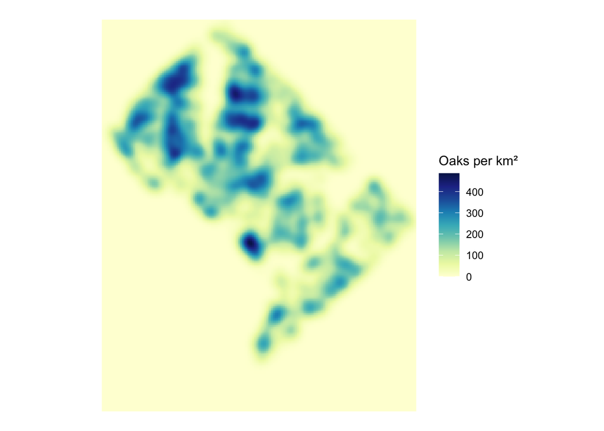

```
[1] "Ward 6"
```